# Spotify Viz

Oscar Leal 1903161

2/16/2020

## Reading the data from TidyTuesdays, and exploring.

```r
spotify_songs <- readr::read_csv('https://raw.githubusercontent.com/rfordatascience/tidytuesday/master/data/2020/2020-01-21/spotify_songs.csv')
tail(spotify_songs)
```

```
## # A tibble: 6 x 23
##   track_id track_name track_artist track_popularity track_album_id
##   <chr>    <chr>      <chr>                   <dbl> <chr>
## 1 0aBDrRT… Many Ways… Ferry Corst…               27 59XOfNjuYZB6f…
## 2 7bxnKAa… City Of L… Lush & Simon               42 2azRoBBWEEEYh…
## 3 5Aevni0… Closer - … Tegan and S…               20 6kD6KLxj7s8eC…
## 4 7ImMqPP… Sweet Sur… Starkillers                14 0ltWNSY9JgxoI…
## 5 2m69mhn… Only For … Mat Zo                     15 1fGrOkHnHJcSt…
## 6 29zWqhc… Typhoon -… Julian Calor               27 0X3mUOm6MhxR7…
## # … with 18 more variables: track_album_name <chr>,
## #   track_album_release_date <chr>, playlist_name <chr>, playlist_id <chr>,
## #   playlist_genre <chr>, playlist_subgenre <chr>, danceability <dbl>,
## #   energy <dbl>, key <dbl>, loudness <dbl>, mode <dbl>, speechiness <dbl>,
## #   acousticness <dbl>, instrumentalness <dbl>, liveness <dbl>, valence <dbl>,
## #   tempo <dbl>, duration_ms <dbl>
```

```r
#typeof(spotify_songs)
spotify_songs <- as.data.table(spotify_songs)
```

Here we see the distributions of genres and subgenres…

```
## 8 columns ignored with more than 50 categories.
## track_id: 28356 categories
## track_name: 23450 categories
## track_artist: 10693 categories
## track_album_id: 22545 categories
## track_album_name: 19744 categories
## track_album_release_date: 4530 categories
## playlist_name: 449 categories
## playlist_id: 471 categories
```

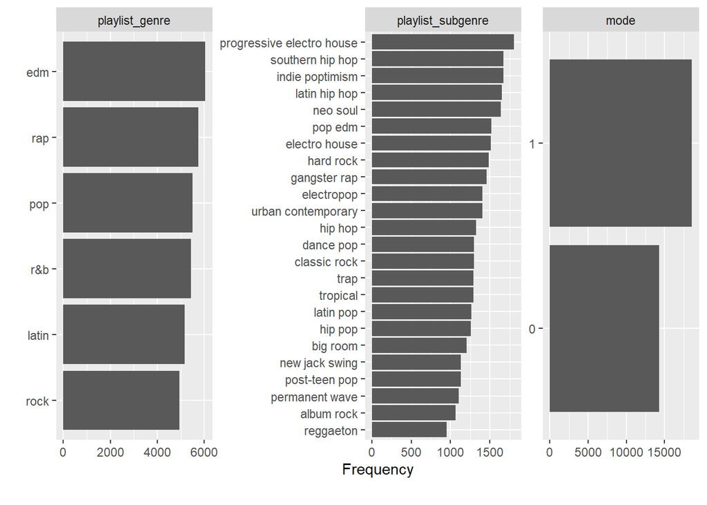

```r
DataExplorer::plot_bar(spotify_songs)
```

Here we can see the Boxplots by Tempo.

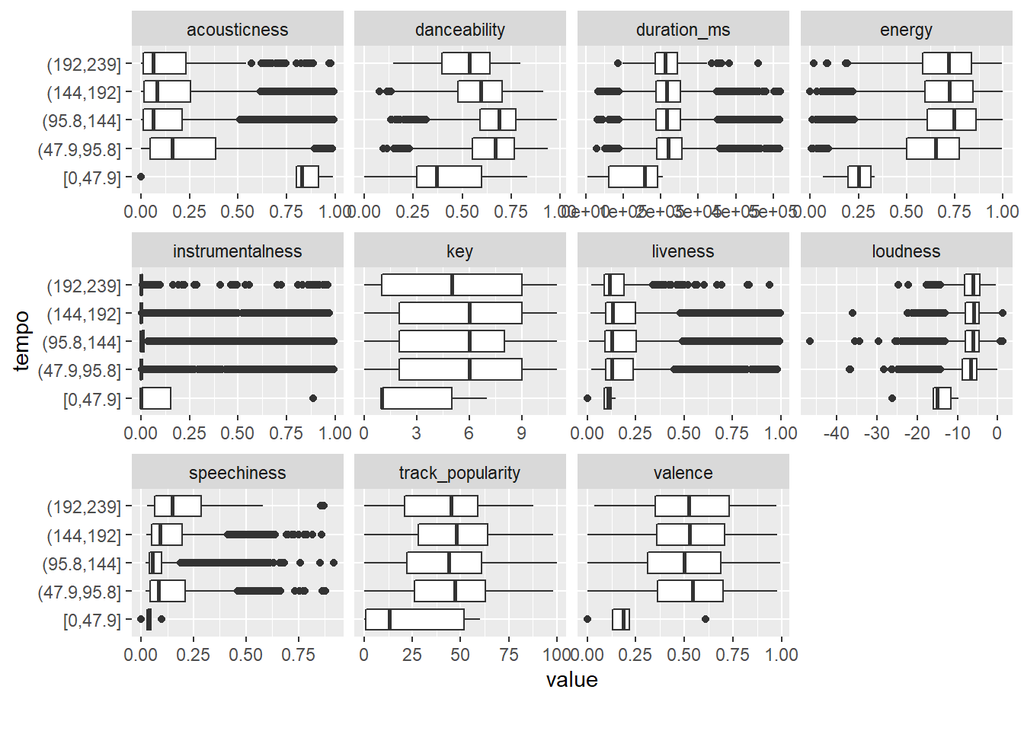

```r
DataExplorer::plot_boxplot(spotify_songs, by = "tempo")
```

```r
skimr::skim(spotify_songs)
```

Data summary

| Name | spotify_songs |
| --- | --- |
| Number of rows | 32833 |
| Number of columns | 23 |
| _______________________ |  |
| Column type frequency: |  |
| character | 10 |
| numeric | 13 |
| ________________________ |  |
| Group variables | None |

**Variable type: character**

| skim_variable | n_missing | complete_rate | min | max | empty | n_unique | whitespace |
| --- | --- | --- | --- | --- | --- | --- | --- |
| track_id | 0 | 1 | 22 | 22 | 0 | 28356 | 0 |
| track_name | 5 | 1 | 1 | 144 | 0 | 23449 | 0 |
| track_artist | 5 | 1 | 2 | 69 | 0 | 10692 | 0 |
| track_album_id | 0 | 1 | 22 | 22 | 0 | 22545 | 0 |
| track_album_name | 5 | 1 | 1 | 151 | 0 | 19743 | 0 |
| track_album_release_date | 0 | 1 | 4 | 10 | 0 | 4530 | 0 |
| playlist_name | 0 | 1 | 6 | 120 | 0 | 449 | 0 |
| playlist_id | 0 | 1 | 22 | 22 | 0 | 471 | 0 |
| playlist_genre | 0 | 1 | 3 | 5 | 0 | 6 | 0 |
| playlist_subgenre | 0 | 1 | 4 | 25 | 0 | 24 | 0 |

**Variable type: numeric**

| skim_variable | n_missing | complete_rate | mean | sd | p0 | p25 | p50 | p75 | p100 | hist |
| --- | --- | --- | --- | --- | --- | --- | --- | --- | --- | --- |
| track_popularity | 0 | 1 | 42.48 | 24.98 | 0.00 | 24.00 | 45.00 | 62.00 | 100.00 | ▆▆▇▆▁ |
| danceability | 0 | 1 | 0.65 | 0.15 | 0.00 | 0.56 | 0.67 | 0.76 | 0.98 | ▁▁▃▇▃ |
| energy | 0 | 1 | 0.70 | 0.18 | 0.00 | 0.58 | 0.72 | 0.84 | 1.00 | ▁▁▅▇▇ |
| key | 0 | 1 | 5.37 | 3.61 | 0.00 | 2.00 | 6.00 | 9.00 | 11.00 | ▇▂▅▅▆ |
| loudness | 0 | 1 | -6.72 | 2.99 | -46.45 | -8.17 | -6.17 | -4.64 | 1.27 | ▁▁▁▂▇ |
| mode | 0 | 1 | 0.57 | 0.50 | 0.00 | 0.00 | 1.00 | 1.00 | 1.00 | ▆▁▁▁▇ |
| speechiness | 0 | 1 | 0.11 | 0.10 | 0.00 | 0.04 | 0.06 | 0.13 | 0.92 | ▇▂▁▁▁ |
| acousticness | 0 | 1 | 0.18 | 0.22 | 0.00 | 0.02 | 0.08 | 0.26 | 0.99 | ▇▂▁▁▁ |
| instrumentalness | 0 | 1 | 0.08 | 0.22 | 0.00 | 0.00 | 0.00 | 0.00 | 0.99 | ▇▁▁▁▁ |
| liveness | 0 | 1 | 0.19 | 0.15 | 0.00 | 0.09 | 0.13 | 0.25 | 1.00 | ▇▃▁▁▁ |
| valence | 0 | 1 | 0.51 | 0.23 | 0.00 | 0.33 | 0.51 | 0.69 | 0.99 | ▃▇▇▇▃ |
| tempo | 0 | 1 | 120.88 | 26.90 | 0.00 | 99.96 | 121.98 | 133.92 | 239.44 | ▁▂▇▂▁ |
| duration_ms | 0 | 1 | 225799.81 | 59834.01 | 4000.00 | 187819.00 | 216000.00 | 253585.00 | 517810.00 | ▁▇▇▁▁ |

After skimming the data we can say we have a nice distribution of numeric and character type variables.

It was interesting to find the variable *danceability* as a value to determine how danceable is a song from 0.0 to 1.0, and how the mean tends to be positive! *Energy* was also positive.

There are some rows with long album names, songs and playlist.

We may convert *key* to factor! Since they are values resembling the overall key of a track.

```r
unique(spotify_songs$key)
```

```
##  [1]  6 11  1  7  8  5  4  2  0 10  9  3
```

```r
#spotify_songs$key <- as.factor(spotify_songs$key)

# Dropping NA values. 5 occurrences, no need to keep!
spotify_songs <- spotify_songs[!(is.na(track_name) & is.na(track_artist) & is.na(track_album_name))]

nrow(spotify_songs) - length(unique(spotify_songs$track_name))
```

```
## [1] 9379
```

```r
toprepeated <- head(spotify_songs[, .(count = .N), by = track_id][count > 1][order(-count)])

topsongsrepeated <- spotify_songs[track_id %in% c(toprepeated$track_id), c('track_name', 'track_artist', 'track_album_name', 'playlist_name', 'playlist_id')][order(track_artist)]

unique(topsongsrepeated$track_artist)
```

```
## [1] "Kygo"             "Riton"            "The Chainsmokers" "Travis Scott"
```

It also seems that there are repeating songs, since there are only 23449 unique values out of 32828 (not including the 5 NAs).

The artists that have repeated songs are Kygo, Riton, The Chainsmokers and Travis Scott, the same song appears in different playlists. Kygo even has two songs that are commonly added to playlists!

```r
spotify_songs[nchar(playlist_name)>100][,.N, by = playlist_name]
```

```
##                                                                                                                                     playlist_name
## 1: Techno House 2020 👽 Best Collection 👻 Top DJ’s Electronic Music - Deep House - Trance - Tech House - Dance - Electro Pop
##     N
## 1: 97
```

```r
nrow(spotify_songs[nchar(playlist_name)>80][,.N, by = playlist_name][order((-N))])
```

```
## [1] 12
```

```r
nrow(spotify_songs[nchar(playlist_name)>50][,.N, by = playlist_name][order((-N))])
```

```
## [1] 33
```

Lets explore the different *valence* by genres. If the value that corresponds to valence is actually the musical positiveness conveyed by a track from a low score (0.0) to a high score (1.0).

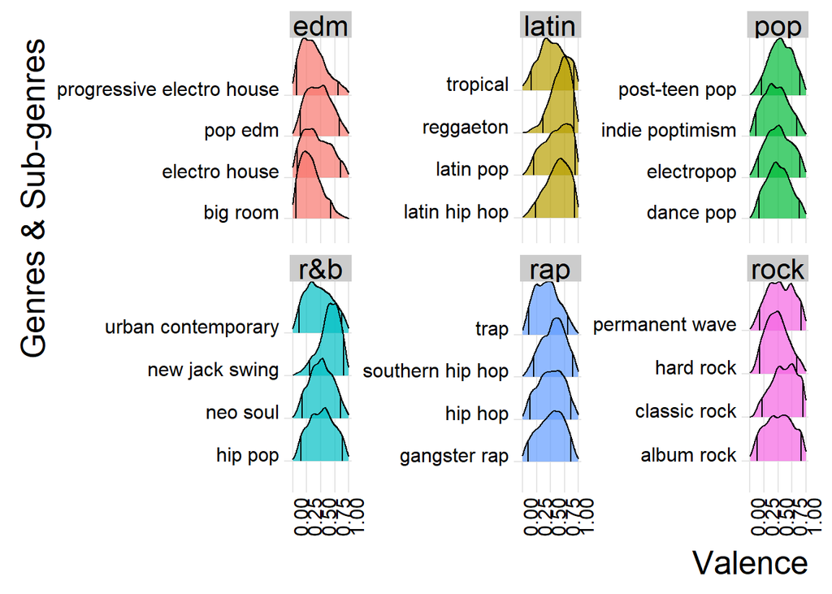

```r
ggplot(
  spotify_songs,
  aes(x = valence, y = playlist_subgenre, fill = playlist_genre),
) +
  ggridges::geom_density_ridges(
    show.legend = FALSE,
    panel_scaling = FALSE,
    quantile_lines = TRUE,
    quantiles = c(.05, .95),
    alpha = .7
  ) +
  facet_wrap(~playlist_genre, scales = "free_y") +
  scale_x_continuous(limits = c(0, 1)) +
  ggridges::theme_ridges() +
  labs(
    y = "Genres & Sub-genres",
    x = "Valence"
  ) +
    theme(text = element_text(size=20),
        axis.text.x = element_text(angle=90, hjust=1))
```

Tracking distribution of length over time. First we transform to date format…

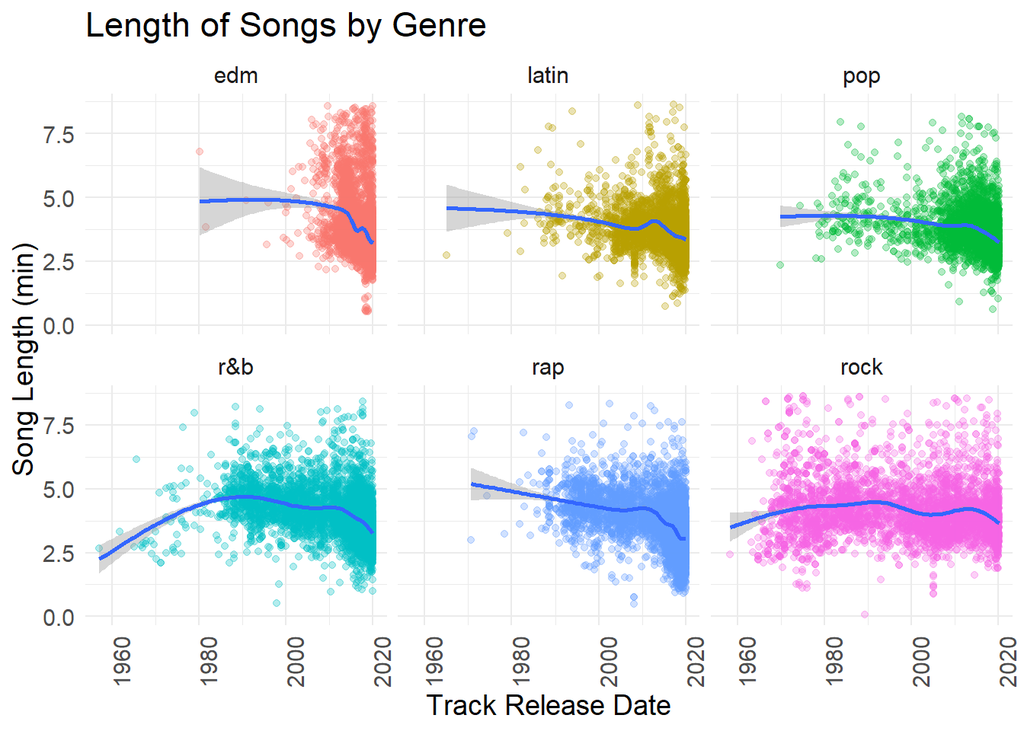

```r
spotify_songs$track_album_release_date = as.Date(spotify_songs$track_album_release_date)

ggplot(spotify_songs, aes(x = track_album_release_date,
                            y = duration_ms / 60000)) +
  geom_point(aes(color = playlist_genre), alpha = 0.3) +
  geom_smooth() +
  facet_wrap(~playlist_genre) +
  labs(x = "Track Release Date",
       y = "Song Length (min)",
       title = "Length of Songs by Genre") +
    theme(text = element_text(size=14),
        axis.text.x = element_text(angle=90, hjust=1),
        legend.position = "none")
```

Unfortunately, in general we have smaller lengths in the present.

Upon finding ggradar:

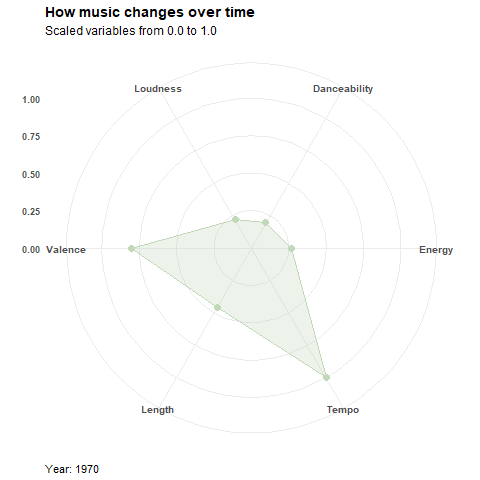

Radar by Year qualitative variables

```r
ggRadar(data = plotdf, aes(group = year), size = 3, ylim = 1.1) +
  scale_color_gradient(low="#C1D8B9", high="#C1D8B9") + scale_fill_gradient(low="#C1D8B9", high="#C1D8B9") +
  theme(legend.position = "none",
        plot.title = element_text(face="bold", size=14),
        plot.subtitle = element_text(size=12),
        axis.text.y = element_text(face="bold"),
        axis.text.x = element_text(face="bold", size = 10),
        axis.title.x = element_text(hjust = 0),
        axis.title.y = element_blank()) +
  labs(title = "How music changes over time",
       subtitle = "Scaled variables from 0.0 to 1.0",
       x = "Year: {frame_time}") +
  transition_time(year) + shadow_mark(alpha=0.1, size=0.5, colour = "grey", fill = "#FFFFFF")

anim_save(filename= "radarchangesovertime.gif", animation = last_animation())
```

Recently songs have trended less energetic, sader, louder, more danceable, and faster.

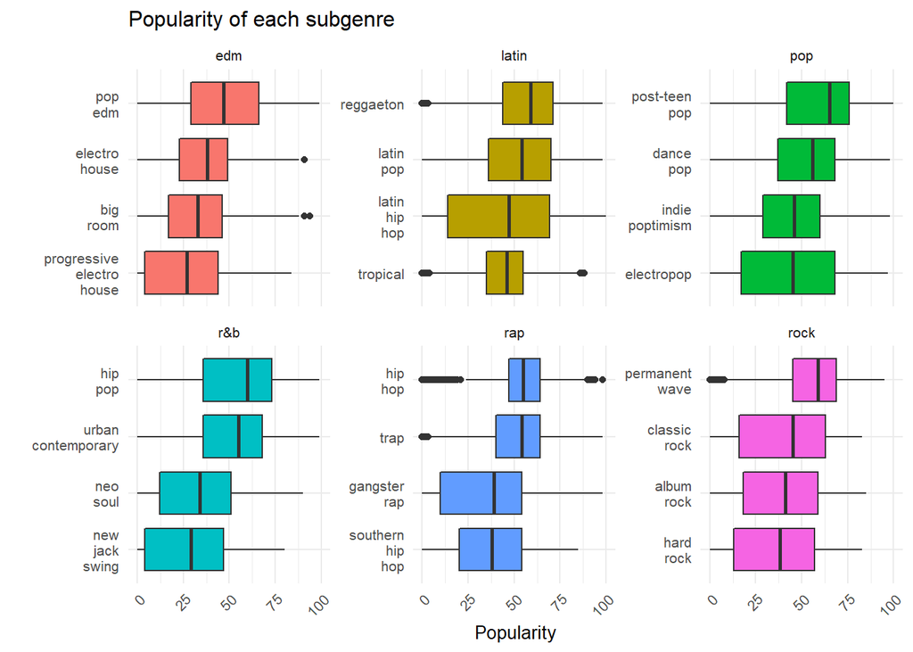

```r
spotify_songs2 <- spotify_songs %>% mutate(playlist_subgenre = fct_reorder(playlist_subgenre, track_popularity))
levels(spotify_songs2$playlist_subgenre) <- gsub(" ", "\n", levels(spotify_songs2$playlist_subgenre))

ggplot(spotify_songs2, aes(y=track_popularity, x=playlist_subgenre,
                          fill = playlist_genre)) + geom_boxplot() +
  #theme(axis.text=element_text(margin = margin(0,1,1,0), angle = 90, hjust = 1)) +
  facet_wrap(~playlist_genre, scales = "free_y") + coord_flip() +
  labs(title = "Popularity of each subgenre",
       y = "Popularity",
       x = "") +
  theme(text = element_text(size=10),
  axis.text.x = element_text(angle=45, hjust=1),
  legend.position = "none")
```

And last but not least, a boxplot showing the popularity of each subgenre.